[Click here to go back](https://www.punitsingh.me/ai.html)

# Bank Fraud

## 1. Import the dataset and explore the data

I am running this script in Google Colab - so you might want to change the location of the dataset and remove the 1st cell.

```python
import warnings
warnings.filterwarnings('ignore')
```

```python
import numpy as np
import pandas as pd
import matplotlib.pyplot as plt

data = pd.read_csv("bs140513_032310.csv")

data.head()
```

|  | step | customer | age | gender | zipcodeOri | merchant | zipMerchant | category | amount | fraud |
| --- | --- | --- | --- | --- | --- | --- | --- | --- | --- | --- |
| 0 | 0 | 'C1093826151' | '4' | 'M' | '28007' | 'M348934600' | '28007' | 'es_transportation' | 4.55 | 0 |
| 1 | 0 | 'C352968107' | '2' | 'M' | '28007' | 'M348934600' | '28007' | 'es_transportation' | 39.68 | 0 |
| 2 | 0 | 'C2054744914' | '4' | 'F' | '28007' | 'M1823072687' | '28007' | 'es_transportation' | 26.89 | 0 |
| 3 | 0 | 'C1760612790' | '3' | 'M' | '28007' | 'M348934600' | '28007' | 'es_transportation' | 17.25 | 0 |
| 4 | 0 | 'C757503768' | '5' | 'M' | '28007' | 'M348934600' | '28007' | 'es_transportation' | 35.72 | 0 |

## Addressing the imbalance in data

From the data description, we know that there are about 600,000 rows of data and only 7200 fraud transactions which is 1.2% of the data which means that there is a massive imbalance in the data.

Assuming that in a real world situation, the number of fraud transactions is very low, so, at first, I will not oversample the data to remove the imbalance in the data. First I will try classifying algorithms on the original dataset and evaluate the results. After that I will repeat the process after removing the imbalance in the data.

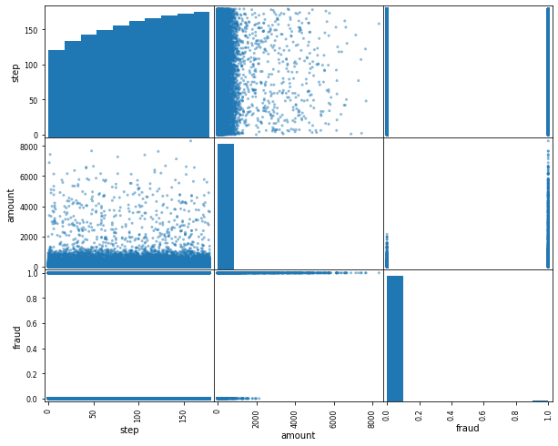

```python
pd.plotting.scatter_matrix(data, figsize = (10,8))
plt.savefig("Scatter_matrix.png")
```

```python
print(data.nunique())
```

```
step             180
customer        4112
age                8
gender             4
zipcodeOri         1
merchant          50
zipMerchant        1
category          15
amount         23767
fraud              2
dtype: int64
```

### Inference

According to the kaggle description of the data, the step parameter shows during which step was a particular transaction added to the dataset in the datacollection process. Since it does not add any important information to this dataset, we can safely drop the "step" column.

According to the BankSim paper [BankSim], the "age" column has categortical values with 0 being age <= 18 and 6 being >65, and U is unknown value. we will procecss Age column as categorical.

The gender column is also categorical with values "Male", "Female", "Enterprise" and "Unknown"

There are 15 unique values in the "category" column so it will also be treated as categorical data.

The fraud column is the output variable where 0 means that the transaction was not fraud and 1 means that the transaction was fraud.

We see that there only one value in the "zipMerchant" and "zipcodeOri" columns. so we can drop these columns.

There is also extra ' ' as the suffix and prefix in the data, so we need to remove that as well.

## 2. Datacleaning and preprocessing

First we drop the NaN values in the dataset.

Then I drop the columns which will not be used.

```python
data = data.dropna()
data = data.drop(["step", "zipcodeOri", "zipMerchant"],  axis = 1)

data['customer'] = data['customer'].str.replace("\'", "")
data['age'] = data['age'].str.replace("\'", "")
data['gender'] = data['gender'].str.replace("\'", "")
data['merchant'] = data['merchant'].str.replace("\'", "")
data['category'] = data['category'].str.replace("\'", "")

data.head()
```

|  | customer | age | gender | merchant | category | amount | fraud |
| --- | --- | --- | --- | --- | --- | --- | --- |
| 0 | C1093826151 | 4 | M | M348934600 | es_transportation | 4.55 | 0 |
| 1 | C352968107 | 2 | M | M348934600 | es_transportation | 39.68 | 0 |
| 2 | C2054744914 | 4 | F | M1823072687 | es_transportation | 26.89 | 0 |
| 3 | C1760612790 | 3 | M | M348934600 | es_transportation | 17.25 | 0 |
| 4 | C757503768 | 5 | M | M348934600 | es_transportation | 35.72 | 0 |

Now I will labelencode the columns which have string values, that is, customer, age, gender, merchant and category columns.

And then I will scale the data using StandardScaler.

```python
from sklearn.preprocessing import LabelEncoder, StandardScaler
le = LabelEncoder()

data["customer"] = le.fit_transform(data["customer"])
data["age"] = le.fit_transform(data["age"])
data["gender"] = le.fit_transform(data["gender"])
data["merchant"] = le.fit_transform(data["merchant"])
data["category"] = le.fit_transform(data["category"])
data.head()
```

|  | customer | age | gender | merchant | category | amount | fraud |
| --- | --- | --- | --- | --- | --- | --- | --- |
| 0 | 210 | 4 | 2 | 30 | 12 | 4.55 | 0 |
| 1 | 2753 | 2 | 2 | 30 | 12 | 39.68 | 0 |
| 2 | 2285 | 4 | 1 | 18 | 12 | 26.89 | 0 |
| 3 | 1650 | 3 | 2 | 30 | 12 | 17.25 | 0 |
| 4 | 3585 | 5 | 2 | 30 | 12 | 35.72 | 0 |

```python
data_x = data[data.columns.difference(["fraud"])]
data_y = data['fraud']

data_x = pd.get_dummies(data_x, columns=['age', 'gender', 'category'])

sc = StandardScaler()
data_x = sc.fit_transform(data_x)
data_x = pd.DataFrame(data_x)
data_x.head()
```

|  | 0 | 1 | 2 | 3 | 4 | 5 | 6 | 7 | 8 | 9 | ... | 20 | 21 | 22 | 23 | 24 | 25 | 26 | 27 | 28 | 29 |
| --- | --- | --- | --- | --- | --- | --- | --- | --- | --- | --- | --- | --- | --- | --- | --- | --- | --- | --- | --- | --- | --- |
| 0 | -0.299276 | -1.545620 | 0.714001 | -0.064347 | -0.329165 | -0.678119 | -0.573390 | 2.110495 | -0.343144 | -0.217136 | ... | -0.057888 | -0.054235 | -0.10179 | -0.02898 | -0.039192 | -0.082315 | -0.063258 | 0.420991 | -0.035011 | -0.161339 |
| 1 | 0.016067 | 0.599484 | 0.714001 | -0.064347 | -0.329165 | 1.474668 | -0.573390 | -0.473822 | -0.343144 | -0.217136 | ... | -0.057888 | -0.054235 | -0.10179 | -0.02898 | -0.039192 | -0.082315 | -0.063258 | 0.420991 | -0.035011 | -0.161339 |
| 2 | -0.098742 | 0.204710 | -0.682938 | -0.064347 | -0.329165 | -0.678119 | -0.573390 | 2.110495 | -0.343144 | -0.217136 | ... | -0.057888 | -0.054235 | -0.10179 | -0.02898 | -0.039192 | -0.082315 | -0.063258 | 0.420991 | -0.035011 | -0.161339 |
| 3 | -0.185275 | -0.330933 | 0.714001 | -0.064347 | -0.329165 | -0.678119 | 1.744015 | -0.473822 | -0.343144 | -0.217136 | ... | -0.057888 | -0.054235 | -0.10179 | -0.02898 | -0.039192 | -0.082315 | -0.063258 | 0.420991 | -0.035011 | -0.161339 |
| 4 | -0.019480 | 1.301303 | 0.714001 | -0.064347 | -0.329165 | -0.678119 | -0.573390 | -0.473822 | 2.914227 | -0.217136 | ... | -0.057888 | -0.054235 | -0.10179 | -0.02898 | -0.039192 | -0.082315 | -0.063258 | 0.420991 | -0.035011 | -0.161339 |

5 rows × 30 columns

```python
print(data_x.nunique())
```

```
0     23767
1      4112
2        50
3         2
4         2
5         2
6         2
7         2
8         2
9         2
10        2
11        2
12        2
13        2
14        2
```

[output cut: 16 more lines]

Then I will split the data into training set and testing set.

```python
data_x.head()
```

|  | 0 | 1 | 2 | 3 | 4 | 5 | 6 | 7 | 8 | 9 | ... | 20 | 21 | 22 | 23 | 24 | 25 | 26 | 27 | 28 | 29 |
| --- | --- | --- | --- | --- | --- | --- | --- | --- | --- | --- | --- | --- | --- | --- | --- | --- | --- | --- | --- | --- | --- |
| 0 | -0.299276 | -1.545620 | 0.714001 | -0.064347 | -0.329165 | -0.678119 | -0.573390 | 2.110495 | -0.343144 | -0.217136 | ... | -0.057888 | -0.054235 | -0.10179 | -0.02898 | -0.039192 | -0.082315 | -0.063258 | 0.420991 | -0.035011 | -0.161339 |
| 1 | 0.016067 | 0.599484 | 0.714001 | -0.064347 | -0.329165 | 1.474668 | -0.573390 | -0.473822 | -0.343144 | -0.217136 | ... | -0.057888 | -0.054235 | -0.10179 | -0.02898 | -0.039192 | -0.082315 | -0.063258 | 0.420991 | -0.035011 | -0.161339 |
| 2 | -0.098742 | 0.204710 | -0.682938 | -0.064347 | -0.329165 | -0.678119 | -0.573390 | 2.110495 | -0.343144 | -0.217136 | ... | -0.057888 | -0.054235 | -0.10179 | -0.02898 | -0.039192 | -0.082315 | -0.063258 | 0.420991 | -0.035011 | -0.161339 |
| 3 | -0.185275 | -0.330933 | 0.714001 | -0.064347 | -0.329165 | -0.678119 | 1.744015 | -0.473822 | -0.343144 | -0.217136 | ... | -0.057888 | -0.054235 | -0.10179 | -0.02898 | -0.039192 | -0.082315 | -0.063258 | 0.420991 | -0.035011 | -0.161339 |
| 4 | -0.019480 | 1.301303 | 0.714001 | -0.064347 | -0.329165 | -0.678119 | -0.573390 | -0.473822 | 2.914227 | -0.217136 | ... | -0.057888 | -0.054235 | -0.10179 | -0.02898 | -0.039192 | -0.082315 | -0.063258 | 0.420991 | -0.035011 | -0.161339 |

5 rows × 30 columns

```python
from sklearn.model_selection import train_test_split
x_train, x_test, y_train, y_test = train_test_split(data_x, data_y, train_size = 0.6)
```

Now that we have a dataset that we can perform operations on, we can proceed with splitting the data into x and y and then into testing and training data.

Now that we have the data split up in different parts, we can apply machiine learning algorithms to the data.

## i.) Applying Classification Algorithms

### a.) SVC

```python
from sklearn.metrics import classification_report
```

```python
from sklearn.svm import SVC
svc = SVC()
svc.fit(x_train, y_train)
y_pred_svc = svc.predict(x_test)

cm_svc = pd.crosstab(y_pred_svc, y_test, rownames = ['pred'], colnames = ['true'], margins = True)
report_svc = classification_report(y_test, y_pred_svc, labels = [0, 1])
print(cm_svc, '\n\n', report_svc)
```

```
true       0     1     All
pred
0     234692   993  235685
1        207  1966    2173
All   234899  2959  237858

               precision    recall  f1-score   support

           0       1.00      1.00      1.00    234899
           1       0.90      0.66      0.77      2959

    accuracy                           0.99    237858
   macro avg       0.95      0.83      0.88    237858
weighted avg       0.99      0.99      0.99    237858
```

SVC takea a lot of time to train the model so we will pass on it in the Cross-Validation data.

### b.) Logistic Regression

```python
from sklearn.linear_model import LogisticRegression
lr = LogisticRegression()
lr.fit(x_train, y_train)
y_pred_lr = lr.predict(x_test)

cm_lr = pd.crosstab(y_pred_lr, y_test, rownames = ['pred'], colnames = ['true'], margins = True)
report_lr = classification_report(y_test, y_pred_lr, labels = [0, 1])
print(cm_lr, '\n\n', report_lr)
```

```
true       0     1     All
pred
0     234724  1121  235845
1        175  1838    2013
All   234899  2959  237858

               precision    recall  f1-score   support

           0       1.00      1.00      1.00    234899
           1       0.91      0.62      0.74      2959

    accuracy                           0.99    237858
   macro avg       0.95      0.81      0.87    237858
weighted avg       0.99      0.99      0.99    237858
```

### c.) Random Forest Classifier

```python
from sklearn.ensemble import RandomForestClassifier
rfc = RandomForestClassifier()
rfc.fit(x_train, y_train)
y_pred_rfc = rfc.predict(x_test)

cm_rfc = pd.crosstab(y_pred_rfc, y_test, rownames = ['pred'], colnames = ['true'], margins = True)
report_rfc = classification_report(y_test, y_pred_rfc, labels = [0, 1])
print(cm_rfc, '\n\n', report_rfc)
```

```
true       0     1     All
pred
0     234588   764  235352
1        311  2195    2506
All   234899  2959  237858

               precision    recall  f1-score   support

           0       1.00      1.00      1.00    234899
           1       0.88      0.74      0.80      2959

    accuracy                           1.00    237858
   macro avg       0.94      0.87      0.90    237858
weighted avg       1.00      1.00      1.00    237858
```

### d.) Decision Tree Classifier

```python
from sklearn.tree import DecisionTreeClassifier
dtc = DecisionTreeClassifier()
dtc.fit(x_train, y_train)
y_pred_dtc = dtc.predict(x_test)

cm_dtc = pd.crosstab(y_pred_dtc, y_test, rownames = ['pred'], colnames = ['true'], margins = True)
report_dtc = classification_report(y_test, y_pred_dtc, labels = [0, 1])
print(cm_dtc, '\n\n', report_dtc)
```

```
true       0     1     All
pred
0     234129   715  234844
1        770  2244    3014
All   234899  2959  237858

               precision    recall  f1-score   support

           0       1.00      1.00      1.00    234899
           1       0.74      0.76      0.75      2959

    accuracy                           0.99    237858
   macro avg       0.87      0.88      0.87    237858
weighted avg       0.99      0.99      0.99    237858
```

```python
from sklearn.linear_model import Ridge
rc = Ridge()
rc.fit(x_train, y_train)
y_pred_rc = dtc.predict(x_test)

cm_rc = pd.crosstab(y_pred_rc, y_test, rownames = ['pred'], colnames = ['true'], margins = True)
report_rc = classification_report(y_test, y_pred_rc, labels = [0, 1])
print(cm_rc, '\n\n', report_rc)
```

```
true       0     1     All
pred
0     234129   715  234844
1        770  2244    3014
All   234899  2959  237858

               precision    recall  f1-score   support

           0       1.00      1.00      1.00    234899
           1       0.74      0.76      0.75      2959

    accuracy                           0.99    237858
   macro avg       0.87      0.88      0.87    237858
weighted avg       0.99      0.99      0.99    237858
```

### f.) ADAoost

```python
from sklearn.ensemble import AdaBoostClassifier
adab = AdaBoostClassifier()
adab.fit(x_train, y_train)
y_pred_adab = adab.predict(x_test)

cm_adab = pd.crosstab(y_pred_adab, y_test, rownames = ['pred'], colnames = ['true'], margins = True)
report_adab = classification_report(y_test, y_pred_adab, labels = [0, 1])
print(cm_adab, '\n\n', report_adab)
```

```
true       0     1     All
pred
0     234623   952  235575
1        276  2007    2283
All   234899  2959  237858

               precision    recall  f1-score   support

           0       1.00      1.00      1.00    234899
           1       0.88      0.68      0.77      2959

    accuracy                           0.99    237858
   macro avg       0.94      0.84      0.88    237858
weighted avg       0.99      0.99      0.99    237858
```

## ii.) Cross-Validation

```python
from sklearn.model_selection import KFold, cross_val_predict
cross_val = KFold(n_splits = 10, random_state= None, shuffle = False)
```

### a.) Logistic Regression

```python
lr_cv = LogisticRegression()
y_pred_lr_cv = cross_val_predict(lr_cv, x_train, y_train, cv = cross_val)
cm_lr_cv = pd.crosstab(y_pred_lr_cv, y_train, rownames = ['pred'], colnames = ['true'], margins = True)
report_lr_cv = classification_report(y_train, y_pred_lr_cv, labels = [0, 1])
print(cm_lr_cv, '\n\n', report_lr_cv)
```

```
true       0     1     All
pred
0     352265  1569  353834
1        279  2672    2951
All   352544  4241  356785

               precision    recall  f1-score   support

           0       1.00      1.00      1.00    352544
           1       0.91      0.63      0.74      4241

    accuracy                           0.99    356785
   macro avg       0.95      0.81      0.87    356785
weighted avg       0.99      0.99      0.99    356785
```

### b.) RFC

```python
rfc_cv = RandomForestClassifier()
y_pred_rfc_cv = cross_val_predict(rfc_cv, x_train, y_train, cv = cross_val)
cm_rfc_cv = pd.crosstab(y_pred_rfc_cv, y_train, rownames = ['pred'], colnames = ['true'], margins = True)
report_rfc_cv = classification_report(y_train, y_pred_rfc_cv, labels = [0, 1])
print(cm_rfc_cv, '\n\n', report_rfc_cv)
```

```
true       0     1     All
pred
0     352078  1045  353123
1        466  3196    3662
All   352544  4241  356785

               precision    recall  f1-score   support

           0       1.00      1.00      1.00    352544
           1       0.87      0.75      0.81      4241

    accuracy                           1.00    356785
   macro avg       0.93      0.88      0.90    356785
weighted avg       1.00      1.00      1.00    356785
```

### c.) DTC

```python
dtc_cv = DecisionTreeClassifier()
y_pred_dtc_cv = cross_val_predict(dtc_cv, x_train, y_train, cv = cross_val)
cm_dtc_cv = pd.crosstab(y_pred_dtc_cv, y_train, rownames = ['pred'], colnames = ['true'], margins = True)
report_dtc_cv = classification_report(y_train, y_pred_dtc_cv, labels = [0, 1])
print(cm_dtc_cv, '\n\n', report_dtc_cv)
```

```
true       0     1     All
pred
0     351462  1040  352502
1       1082  3201    4283
All   352544  4241  356785

               precision    recall  f1-score   support

           0       1.00      1.00      1.00    352544
           1       0.75      0.75      0.75      4241

    accuracy                           0.99    356785
   macro avg       0.87      0.88      0.87    356785
weighted avg       0.99      0.99      0.99    356785
```

### d.) Ridge Classifier

```python
rc_cv = Ridge()
```

### e.) ADABoost

```python
adab_cv = AdaBoostClassifier()
y_pred_adab_cv = cross_val_predict(adab_cv, x_train, y_train, cv = cross_val)
cm_adab_cv = pd.crosstab(y_pred_adab_cv, y_train, rownames = ['pred'], colnames = ['true'], margins = True)
report_adab_cv = classification_report(y_train, y_pred_adab_cv, labels = [0, 1])
print(cm_adab_cv, '\n\n', report_adab_cv)
```

```
true       0     1     All
pred
0     352118  1335  353453
1        426  2906    3332
All   352544  4241  356785

               precision    recall  f1-score   support

           0       1.00      1.00      1.00    352544
           1       0.87      0.69      0.77      4241

    accuracy                           1.00    356785
   macro avg       0.93      0.84      0.88    356785
weighted avg       0.99      1.00      0.99    356785
```

```
   customer  age  gender  merchant  category  amount  fraud
0       210    4       2        30        12    4.55      0
1      2753    2       2        30        12   39.68      0
2      2285    4       1        18        12   26.89      0
3      1650    3       2        30        12   17.25      0
4      3585    5       2        30        12   35.72      0
   customer  age  gender  merchant  category  amount
0       210    4       2        30        12    4.55
1      2753    2       2        30        12   39.68
2      2285    4       1        18        12   26.89
3      1650    3       2        30        12   17.25
4      3585    5       2        30        12   35.72
explained variance ratio:

 [9.91188343e-01 8.75286931e-03 5.21648564e-05 5.18593705e-06
 1.25847043e-06 1.78590666e-07]
```

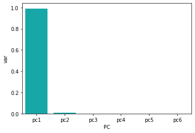

```python
print(data.head())

cols = ["customer", "age", "gender", "merchant", "category", "amount"]
data_x_pca = data[data.columns.difference(["fraud"])]
data_x_pca = data_x_pca[cols]
print(data_x_pca.head())


import seaborn as sns
from sklearn.decomposition import PCA, FactorAnalysis

pca = PCA()
data_x_pca = pca.fit(data_x_pca)
pca_components = pca.components_

print("explained variance ratio:\n\n", pca.explained_variance_ratio_)

var_ratio = pd.DataFrame({'var':pca.explained_variance_ratio_,
             'PC':['pc1','pc2','pc3','pc4','pc5','pc6']})

sns.barplot(x = 'PC', y = 'var', data=var_ratio, color="c");
```

# Analysis

[output not shown]

Using Cross-Validation

[output not shown]

# Addressing the data Imbalance

I will address the imbalance in the data by oversampling the fraud values using SMOTE

```python
data.head()
data_x_over = data_x
data_y_over = data_y

from imblearn.over_sampling import SMOTE

over = SMOTE()
data_x_over, data_y_over = over.fit_resample(data_x_over, data_y_over)
data_y_over = pd.DataFrame(data_y_over)
print(data_y_over.iloc[0].value_counts())
```

```
0    1
Name: 0, dtype: int64
```

```python
x_over_train, x_over_test, y_over_train, y_over_test = train_test_split(data_x_over, data_y_over, train_size =0.7 )
```

```python
dtc.fit(x_over_train, y_over_train)
y_pred_over = dtc.predict(x_over_test)
y_pred_over = np.array(y_pred_over)
y_over_test = np.array(y_over_test)
y_over_test = y_over_test.reshape(-1,)
print(y_pred_over.shape, y_over_test.shape)
```

```
(352466,) (352466,)
```

```python
cm_dtc_over = pd.crosstab(y_pred_over, y_over_test, rownames = ['pred'], colnames = ['true'], margins = True)
report_dtc_over = classification_report(y_over_test, y_pred_over, labels = [0, 1])
print( cm_dtc_over, '\n\n', report_dtc_over)
```

```
true       0       1     All
pred
0     174267    1560  175827
1       2109  174530  176639
All   176376  176090  352466

               precision    recall  f1-score   support

           0       0.99      0.99      0.99    176376
           1       0.99      0.99      0.99    176090

    accuracy                           0.99    352466
   macro avg       0.99      0.99      0.99    352466
weighted avg       0.99      0.99      0.99    352466
```

# Conclusion